Skip to contents

# Material validation

Transmission and reflection against DIN/TS 67600

2026-10-09

Source: [`vignettes/articles/Material_Validation.qmd`](https://github.com/LiTGde/Spectran/blob/main/vignettes/articles/Material_Validation.qmd)

## Preface

This article extends the spectral validation to Spectran’s **Transmission / Reflection** module. It compares photopic and melanopic material coefficients with **DIN/TS 67600:2022-08, Tables 6 to 10**. The article shows the calculations, reference values and signed differences.

The scope follows the DIN material tables: transmission under **D65**, and reflection under **EE, A, D65, FL11, LED-B1, LED-B2, LED-B3 and LED-B5**. Each material is compared only under the illuminants for which its DIN table supplies coefficients. Comparisons use documented TUB sample assignments. Materials without an assigned spectrum remain in the reference inventory.

The [TUB dataset, version 2](https://doi.org/10.14279/depositonce-11893.2), is explicitly referenced in DIN/TS 67600, Section 6.2.4.1 and reference [43]. Its [documentation](https://depositonce.tu-berlin.de/bitstreams/fb974995-09e8-4448-a0ee-95ddc66230f6/download), pp. 2, 6 and 9, describes the measurement programme, specimens and transmission data. This source relationship does not provide a complete specimen mapping for DIN Tables 7 and 8.

## Table preparation

### Setup and reference input

All scientific calculations use R and the current Spectran source. Loading the project with `pkgload::load_all()` ensures that the article tests the module in the working copy. Internal module functions are called deliberately here because this article checks their implementation.

**Setup**

```r
suppressPackageStartupMessages({
  library(dplyr)
  library(tidyr)
  library(purrr)
  library(ggplot2)
  library(gt)
})

root <- rprojroot::find_root(rprojroot::has_file("DESCRIPTION"))
pkgload::load_all(root, quiet = TRUE)
data_dir <- file.path(root, "vignettes/articles/material-validation-data")
response_labels <- c(vis = "Photopic", mel = "Melanopic")
theme_set(cowplot::theme_cowplot(font_size = 11, font_family = "sans"))

fmt <- function(x, digits = 3) formatC(x, digits = digits, format = "f")
sci_prose <- function(x, digits = 2) {
  if (x == 0) return("0")
  parts <- strsplit(formatC(x, format = "e", digits = digits), "e", fixed = TRUE)[[1]]
  paste0("$", parts[1], "\\times 10^{", as.integer(parts[2]), "}$")
}
```

The prepared DIN coefficient CSV contains one row per material and evaluating illuminant. It records the original German designation, an English translation, transmission or reflection, the photopic coefficient `din_vis`, the melanopic coefficient `din_mel`, and the DIN table and printed page. Both coefficients are dimensionless fractions. The nonvisual quantity considered here is the melanopic coefficient.

The 260 rows cover all 71 materials in Tables 6 to 10. The unglazed reference in Table 6 is not an additional material. CSV preparation is a separate, documented step; rendering this article requires no PDF extraction or table parsing. The data notes describe the fields and preparation script.

**Calculation**

```r
din_file <- file.path(data_dir, "din-67600-material-coefficients.csv")
assignment_file <- file.path(data_dir, "tub-assignments.csv")

din_coefficients <- read.csv(din_file, fileEncoding = "UTF-8") |> as_tibble()
assignments <- read.csv(assignment_file, fileEncoding = "UTF-8") |> as_tibble()

stopifnot(
  nrow(din_coefficients) == 260L,
  n_distinct(din_coefficients$din_id) == 71L,
  !anyDuplicated(din_coefficients[c("din_id", "illuminant")]),
  !anyNA(din_coefficients[c("din_vis", "din_mel")])
)
```

**Table and thumbnail styling**

```r
style_table <- function(x) {
  x |>
    opt_align_table_header(align = "left") |>
    tab_options(
      table.font.names = c("Arial", "Helvetica", "sans-serif"),
      table.font.size = px(13), table.width = pct(100),
      data_row.padding = px(6), column_labels.font.weight = "bold",
      table.border.top.width = px(2), table.border.bottom.width = px(2),
      container.overflow.x = "auto"
    )
}

thumbnail <- function(data, alt) {
  plot <- ggplot(data, aes(wavelength, value)) +
    geom_rect(aes(xmin = wavelength - 0.5, xmax = wavelength + 0.5,
      ymin = 0, ymax = value, fill = colour), colour = NA) +
    geom_line(colour = "#222222", linewidth = 0.3) +
    scale_fill_identity() +
    scale_x_continuous(breaks = c(380, 780), expand = expansion(mult = 0)) +
    scale_y_continuous(breaks = c(0, 1), expand = expansion(mult = 0)) +
    coord_cartesian(xlim = c(380, 780), ylim = c(0, 1.03)) +
    labs(x = NULL, y = NULL) +
    theme_classic(base_size = 6) +
    theme(
      axis.line = element_line(linewidth = 0.2),
      axis.ticks = element_line(linewidth = 0.2),
      axis.ticks.length = grid::unit(1, "pt"),
      plot.margin = margin(2, 2, 2, 2)
    )

  image_file <- tempfile(fileext = ".png")
  on.exit(unlink(image_file))
  ggsave(image_file, plot = plot, width = 93 / 96, height = 60 / 96,
    units = "in", dpi = 192, bg = "white", limitsize = FALSE)
  tag <- as.character(gt::local_image(image_file, height = 60))
  sub("<img ", paste0('<img alt="', htmltools::htmlEscape(alt, attribute = TRUE),
    '" '), tag, fixed = TRUE)
}
```

### DIN materials and TUB assignments

The DIN tables contain 12 glazing samples, 11 multi-skin sheets, 21 plastics or filters, and 27 reflecting surfaces. Tables 9 and 10 reuse the same surface samples.

The assignment CSV links 39 DIN materials to TUB catalogue records. Wood identifiers follow the specimen order in the TUB documentation because the original CSV repeats a wood heading. For S1, DIN describes yellow brick whereas TUB describes beige brick. The comparison tables retain the TUB glazing constructions and this difference in the brick description. Numeric agreement is not used to select specimens.

**Calculation**

```r
records <- Spectran:::tub_material_records |>
  select(catalogue_id, display_name_en, source_file, source_column, source_column_header)

materials <- din_coefficients |>
  distinct(din_id, din_name_en, mode, group) |>
  left_join(assignments, by = "din_id", relationship = "one-to-one") |>
  left_join(records, by = "catalogue_id", relationship = "many-to-one") |>
  mutate(
    material = coalesce(sub("^[^·]+ · ", "", display_name_en), din_name_en),
    material = if_else(din_id == 416L, "Yellow brick (TUB: beige)", material),
    curve_available = !is.na(catalogue_id)
  )

stopifnot(nrow(materials) == 71L, !anyNA(materials$material),
  sum(materials$curve_available) == 39L)

coverage <- materials |>
  summarise(Materials = n(), Assigned = sum(curve_available),
    Missing = sum(!curve_available), .by = group)
```

**Format the coverage table**

```r
coverage |>
  gt(rowname_col = "group") |>
  cols_label(Assigned = "Assigned spectra", Missing = "No confirmed spectrum") |>
  fmt_integer(columns = where(is.numeric)) |>
  style_table()
```

Table 1: Coverage of the DIN material examples by documented TUB assignments.

|  | Materials | Assigned spectra | No confirmed spectrum |
| --- | --- | --- | --- |
| Glazing | 12 | 12 | 0 |
| Multi-skin sheets | 11 | 0 | 11 |
| Plastics and filters | 21 | 0 | 21 |
| Surfaces | 27 | 27 | 0 |

### Preparing the DIN illuminants

The source key `CIE:E` represents the equal-energy illuminant labelled **EE** in DIN. Each source is linearly interpolated onto 380–780 nm at 1 nm intervals and scaled to 100 lx using the material module. A scalar change in source intensity cancels in a material coefficient. The thumbnail copies are separately divided by their peak solely to display spectral shape on a common 0–1 scale.

**Calculation**

```r
sources <- din_coefficients |>
  distinct(illuminant) |>
  mutate(
    source_name = if_else(illuminant == "EE", "E", gsub("-", "_", illuminant)),
    source_id = paste0("CIE:", source_name)
  ) |>
  arrange(match(illuminant, c("EE", "A", "D65", "FL11", "LED-B1", "LED-B2", "LED-B3", "LED-B5")))

din_reference <- din_coefficients |>
  select(din_id, illuminant, din_table_ref, page, din_vis, din_mel) |>
  left_join(select(sources, illuminant, source_id),
    by = "illuminant", relationship = "many-to-one") |>
  pivot_longer(c(din_vis, din_mel), names_to = "response",
    names_prefix = "din_", values_to = "din") |>
  select(-illuminant)

source_spectra <- map(sources$source_name, function(name) {
  raw <- Spectran::examplespectra$CIE |>
    filter(between(Wellenlaenge, 380, 780)) |>
    select(Wellenlaenge, all_of(name))
  stopifnot(all(is.finite(as.matrix(raw))), !anyDuplicated(raw[[1]]),
    min(raw[[1]]) == 380, max(raw[[1]]) == 780)

  spectrum <- tibble(
    Wellenlaenge = 380:780,
    Bestrahlungsstaerke = approx(raw[[1]], raw[[2]], xout = 380:780)$y
  )
  Spectran:::material_scale_light(spectrum, 100)
}) |>
  setNames(sources$source_id)

stopifnot(all(map_lgl(source_spectra, function(s) {
  all(is.finite(s$Bestrahlungsstaerke)) && all(s$Bestrahlungsstaerke >= 0)
})))
```

## Calculation

For incident spectrum $S(\lambda)$, material spectrum $c(\lambda)$ and weighting function $w(\lambda)$, the coefficient is

$$c_w(S)=\frac{\int_{380}^{780} S(\lambda)c(\lambda)w(\lambda)\,\mathrm d\lambda}
{\int_{380}^{780} S(\lambda)w(\lambda)\,\mathrm d\lambda}.
\qquad(1)$$

Here $c=\tau$ for transmission and $c=\rho$ for reflection. The photopic weighting is $V(\lambda)$; the melanopic weighting is $s_{\mathrm{mel}}(\lambda)$. Both are taken from `Specs$AS_wide`. For illuminants other than D65, DIN also uses the designation $k_{\mathrm{mel}}$ for the melanopic material factor. We compare the weighted material coefficients, not MDER or effective MDER.

Spectran linearly interpolates the TUB material samples from 5 nm to 1 nm and sums over 380–780 nm, including both endpoints. The common wavelength increment cancels in the quotient. The outgoing spectrum is not renormalised when calculating a material coefficient.

**Calculation**

```r
mapped <- filter(materials, curve_available)
material_preparation <- map(mapped$catalogue_id, function(id) {
  curve <- Spectran:::transmission_catalogue_record(id)$curve
  stopifnot(identical(as.numeric(curve$wavelength_nm), seq(380, 780, 5)))

  raw <- data.frame(wavelength_nm = curve$wavelength_nm, value = curve$transmittance)
  prepared <- Spectran:::prepare_transmission_curve(raw, scale = "fraction")$completed
  stopifnot(all(is.finite(prepared$transmittance)),
    all(prepared$status %in% c("supplied", "interpolated")))
  prepared
}) |>
  setNames(mapped$catalogue_id)

weights <- list(
  vis = Spectran::Specs$AS_wide[["V(lambda)"]],
  mel = Spectran::Specs$AS_wide$Melanopsin
)
stopifnot(identical(as.numeric(Spectran::Specs$AS_wide$Wellenlaenge), as.numeric(380:780)))
```

### Worked example: DIN 106 / TUB G6 under D65

The numerator describes the transmitted, weighted spectrum. The denominator describes the incident, weighted spectrum. Their ratio is dimensionless.

**Calculation**

```r
s <- source_spectra[["CIE:D65"]]$Bestrahlungsstaerke
c_material <- material_preparation[["tub:transmission:G6"]]$transmittance

example_terms <- imap(weights, function(w, response) {
  numerator <- sum(s * c_material * w)
  denominator <- sum(s * w)
  tibble(
    Response = unname(response_labels[response]),
    Numerator = numerator, Denominator = denominator,
    Coefficient = numerator / denominator
  )
}) |>
  list_rbind()
```

**Format the worked example**

```r
example_terms |>
  gt(rowname_col = "Response") |>
  fmt_number(columns = where(is.numeric), decimals = 6) |>
  style_table()
```

Table 2: Explicit weighted sums for DIN 106 / TUB G6 under D65.

|  | Numerator | Denominator | Coefficient |
| --- | --- | --- | --- |
| Photopic | 0.105421 | 0.146413 | 0.720027 |
| Melanopic | 0.093267 | 0.132621 | 0.703261 |

The resulting photopic coefficient is 0.720027 and the melanopic coefficient is 0.703261.

### Checking the material module

For every confirmed material–illuminant pair in the DIN tables, we execute both the module and the explicit weighted sums. The module field `active_metrics$comparison_value` supplies the outgoing-to-incident ratio. This is an implementation check, not an independent test of the input spectra.

**Calculation**

```r
coefficient_values <- function(catalogue_id, source_id, mode) {
  spectrum <- source_spectra[[source_id]]
  curve <- material_preparation[[catalogue_id]]
  result <- Spectran:::calculate_material_result(spectrum, curve, tolower(mode))
  metric_ids <- c(vis = "photopic_illuminance", mel = "melanopic_irradiance")

  imap(weights, function(w, response) {
    numerator <- sum(spectrum$Bestrahlungsstaerke * curve$transmittance * w)
    denominator <- sum(spectrum$Bestrahlungsstaerke * w)
    value <- result$active_metrics$comparison_value[
      result$active_metrics$metric_id == metric_ids[[response]]
    ]
    stopifnot(length(value) == 1L, is.finite(value), denominator > 0)

    tibble(
      catalogue_id, source_id, response,
      spectran = value, numerator, denominator,
      explicit = numerator / denominator
    )
  }) |>
    list_rbind()
}

pairs <- din_reference |>
  distinct(din_id, source_id) |>
  inner_join(select(mapped, din_id, catalogue_id, mode),
    by = "din_id", relationship = "many-to-one")

calculated <- pmap(pairs, function(din_id, source_id, catalogue_id, mode) {
  coefficient_values(catalogue_id, source_id, mode) |>
    mutate(din_id = din_id)
}) |>
  list_rbind()

internal_max <- max(abs(calculated$spectran - calculated$explicit))
stopifnot(internal_max <= 1e-12)
```

The module and the explicit sums agree within $10^{-12}$ for all 456 coefficients (228 material–illuminant pairs). The maximum absolute difference is 0.

### Differences and rounding

We report $\Delta=c_{\mathrm{Spectran}}-c_{\mathrm{DIN}}$, its percentage-point form $100\Delta$, and the relative difference $100\Delta/c_{\mathrm{DIN}}$. Positive values mean that Spectran is higher. Relative differences are undefined for a zero DIN value.

The strict rounding interval is **±0.0005** for a DIN coefficient printed to three decimals. A second, project-defined **reproduction limit of ±0.001** (±0.10 percentage points) also allows for TUB spectral coefficients rounded to three decimals. With nonnegative weights, rounding each input coefficient to the nearest 0.001 can change the weighted mean by at most 0.0005. Adding the two rounding bounds gives 0.001. This is neither a DIN conformity tolerance nor measurement uncertainty, and it does not explain the cause of any individual difference.

**Calculation**

```r
material_details <- materials |>
  select(din_id, material, mode, group, catalogue_id, curve_available)
calculation_details <- calculated |>
  select(din_id, source_id, response, spectran, numerator, denominator, explicit)

comparison <- din_reference |>
  left_join(material_details, by = "din_id", relationship = "many-to-one") |>
  left_join(calculation_details,
    by = c("din_id", "source_id", "response"), relationship = "one-to-one") |>
  left_join(select(sources, source_id, illuminant),
    by = "source_id", relationship = "many-to-one") |>
  mutate(
    difference = spectran - din,
    difference_pp = 100 * difference,
    relative_difference_percent = if_else(din != 0, 100 * difference / din, NA_real_),
    within_rounding = abs(difference) <= 0.0005,
    within_budget = abs(difference) <= 0.001,
    status = case_when(
      !curve_available ~ "No confirmed spectrum",
      within_rounding ~ "Within rounding",
      within_budget ~ "Within reproduction limit",
      TRUE ~ "Outside reproduction limit"
    )
  )

stopifnot(nrow(comparison) == 520L)
paired <- filter(comparison, curve_available)
wide <- comparison |>
  select(din_id, material, mode, catalogue_id, curve_available, source_id,
    illuminant, response, din, spectran, difference_pp, relative_difference_percent) |>
  pivot_wider(
    names_from = response,
    values_from = c(din, spectran, difference_pp, relative_difference_percent)
  )
```

## Results

The overview includes only confirmed assignments with both DIN and Spectran values. The result tables below pair each material curve with the applicable illuminant curve; the material plots retain absolute coefficients on a 0–1 scale, whereas illuminant plots show peak-normalised spectral power. All thumbnails span 380–780 nm. Their filled areas use Spectran’s `Lang` wavelength palette. These colours indicate wavelength and do not predict the perceived colour of a material or reproduce monochromatic light faithfully on a screen.

**Calculation**

```r
summary_by_response <- paired |>
  summarise(
    Coefficients = n(), Rounding = sum(within_rounding),
    Reproduced = sum(within_budget), Outside = sum(!within_budget),
    median_abs_pp = median(abs(difference_pp)),
    max_abs_pp = max(abs(difference_pp)),
    .by = c(mode, response)
  )

summary_by_source <- paired |>
  summarise(
    Coefficients = n(), Outside = sum(!within_budget),
    max_abs_pp = max(abs(difference_pp)),
    .by = c(mode, illuminant, response)
  )
```

**Format the overview**

```r
summary_by_response |>
  mutate(response = unname(response_labels[response])) |>
  gt(groupname_col = "mode", rowname_col = "response") |>
  cols_label(Coefficients = "n", Rounding = html("Within<br>±0.0005"),
    Reproduced = html("Within<br>±0.001"), Outside = "Outside",
    median_abs_pp = html("Median |Δ|<br>(pp)"), max_abs_pp = html("Max. |Δ|<br>(pp)")) |>
  fmt_integer(columns = c(Coefficients, Rounding, Reproduced, Outside)) |>
  fmt_number(columns = c(median_abs_pp, max_abs_pp), decimals = 4) |>
  style_table() |>
  tab_source_note("pp = percentage points.")
```

Table 3: Agreement for confirmed assignments. The reproduction count includes the stricter rounding count.

|  | n | Within ±0.0005 | Within ±0.001 | Outside | Median \|Δ\| (pp) | Max. \|Δ\| (pp) |
| --- | --- | --- | --- | --- | --- | --- |
| Transmission |  |  |  |  |  |  |
| Photopic | 12 | 12 | 12 | 0 | 0.0208 | 0.0462 |
| Melanopic | 12 | 12 | 12 | 0 | 0.0227 | 0.0436 |
| Reflection |  |  |  |  |  |  |
| Photopic | 216 | 186 | 191 | 25 | 0.0268 | 2.1210 |
| Melanopic | 216 | 207 | 216 | 0 | 0.0290 | 0.0996 |

pp = percentage points.

**Calculation**

```r
figure_overview_data <- paired |>
  mutate(
    illuminant = factor(illuminant, levels = sources$illuminant),
    response = factor(response, levels = names(response_labels), labels = response_labels)
  )

ggplot(figure_overview_data, aes(illuminant, difference_pp, colour = mode, shape = mode)) +
  geom_hline(yintercept = 0, colour = "grey70", linewidth = 0.3) +
  geom_hline(yintercept = c(-0.1, 0.1), linetype = "dashed",
    colour = "grey45", linewidth = 0.35) +
  geom_point(size = 1.7, alpha = 0.65, position = position_dodge(width = 0.3)) +
  facet_wrap(~ response, nrow = 1) +
  scale_colour_manual(values = c(Reflection = "#264E86", Transmission = "#B04A32")) +
  scale_shape_manual(values = c(Reflection = 17, Transmission = 16)) +
  labs(x = "Illuminant", y = "Spectran − DIN (percentage points)", colour = NULL, shape = NULL) +
  theme(legend.position = "bottom", axis.text.x = element_text(angle = 45, hjust = 1))
```

[figure not shown]

Figure 1: Signed differences for confirmed assignments. Dashed lines mark the project reproduction limit of ±0.10 percentage points; the two panels use the same vertical scale.

**Prepare the two spectral thumbnails and format the result tables**

```r
wavelength_colours <- tibble(
  wavelength = 380:780,
  colour = unname(Spectran::ColorP$Lang[as.character(380:780)])
)
stopifnot(!anyNA(wavelength_colours))

source_thumbnails <- map(source_spectra, function(s) {
  tibble(wavelength = s$Wellenlaenge,
    value = s$Bestrahlungsstaerke / max(s$Bestrahlungsstaerke)) |>
    left_join(wavelength_colours, by = "wavelength", relationship = "one-to-one")
})
material_thumbnails <- map(material_preparation, function(curve) {
  tibble(wavelength = curve$wavelength_nm, value = curve$transmittance) |>
    left_join(wavelength_colours, by = "wavelength", relationship = "one-to-one")
})

source_images <- imap_chr(source_thumbnails, function(data, id) {
  label <- sources$illuminant[match(id, sources$source_id)]
  image <- thumbnail(data, paste(label, "relative spectral power, 380–780 nm"))
  paste0(image, '<br><span class="spectrum-label">', label, '</span>')
})
material_images <- imap_chr(material_thumbnails, function(data, id) {
  label <- materials$material[match(id, materials$catalogue_id)]
  thumbnail(data, paste(label, "material coefficient, 380–780 nm"))
})

signed_cell <- function(x, digits = 3, mark_limit = FALSE) {
  map_chr(x, function(value) {
    if (is.na(value)) return("NA")
    # Suppress a negative sign only when the displayed value rounds to zero.
    displayed <- if (round(value, digits) == 0) 0 else value
    label <- formatC(displayed, format = "f", digits = digits, flag = "+")
    if (mark_limit && abs(value) > 0.1) {
      paste0('<span class="outside-limit"><strong>', label, '</strong></span>')
    } else {
      label
    }
  })
}

result_table <- function(data) {
  table_data <- data |>
    mutate(
      identity = paste0(din_id, "<br><span class='sample-id'>",
        sub("tub:(transmission|reflection):", "", catalogue_id), "</span>"),
      material_plot = unname(material_images[catalogue_id]),
      source_plot = unname(source_images[source_id]),
      response = "vis<br>mel"
    ) |>
    select(identity, material, material_plot, source_plot, response,
      din_vis, din_mel, spectran_vis, spectran_mel, difference_pp_vis,
      difference_pp_mel, relative_difference_percent_vis, relative_difference_percent_mel)

  table_data |>
    gt() |>
    fmt_number(columns = c(din_vis, din_mel), decimals = 3) |>
    fmt_number(columns = c(spectran_vis, spectran_mel), decimals = 5) |>
    gt::fmt(columns = c(difference_pp_vis, difference_pp_mel),
      fns = function(x) signed_cell(x, mark_limit = TRUE)) |>
    gt::fmt(columns = c(relative_difference_percent_vis, relative_difference_percent_mel),
      fns = signed_cell) |>
    sub_missing(missing_text = "NA") |>
    cols_merge(columns = c(din_vis, din_mel), pattern = "{1}<br>{2}") |>
    cols_merge(columns = c(spectran_vis, spectran_mel), pattern = "{1}<br>{2}") |>
    cols_merge(columns = c(difference_pp_vis, difference_pp_mel), pattern = "{1}<br>{2}") |>
    cols_merge(columns = c(relative_difference_percent_vis, relative_difference_percent_mel),
      pattern = "{1}<br>{2}") |>
    fmt_markdown(columns = c(identity, material_plot, source_plot, response)) |>
    cols_label(
      identity = html("DIN<br>TUB"), material = "Material description",
      material_plot = "Material", source_plot = "Illuminant", response = "Weight",
      din_vis = "DIN", spectran_vis = "Spectran",
      difference_pp_vis = html("Δ<br>(pp)"),
      relative_difference_percent_vis = html("Δ<br>(%)")
    ) |>
    cols_align(align = "left", columns = material) |>
    cols_align(align = "center", columns = c(identity, material_plot, source_plot, response)) |>
    cols_align(align = "right",
      columns = c(din_vis, spectran_vis, difference_pp_vis, relative_difference_percent_vis)) |>
    cols_width(
      identity ~ px(42), material ~ px(154), material_plot ~ px(80), source_plot ~ px(80),
      response ~ px(45), din_vis ~ px(62), spectran_vis ~ px(69),
      difference_pp_vis ~ px(62), relative_difference_percent_vis ~ px(63)
    ) |>
    style_table() |>
    # Preserve paired cell formatting and column widths through Quarto/pkgdown.
    tab_options(table.font.size = px(12), data_row.padding = px(4),
      quarto.disable_processing = TRUE) |>
    tab_source_note(html(paste0(
      "Within each cell: <b>vis</b> (photopic), then <b>mel</b> (melanopic). ",
      "Δ = Spectran − DIN. pp = percentage points; % = relative difference. ",
      "Bold red Δ values exceed ±0.10 pp. ",
      "Thumbnails: 380–780 nm; material 0–1; illuminant peak = 1."
    )))
}
```

### Transmission

#### Confirmed glazing assignments

Table 6 supplies D65 coefficients for the 12 glazing samples. These are the confirmed transmission comparisons. Five decimal places are retained for Spectran to make small differences visible; they do not imply equivalent measurement accuracy.

Each numeric cell lists **photopic (vis)** above **melanopic (mel)** values. Δ = Spectran − DIN; **pp** = percentage points; **%** = relative difference. Bold red Δ values exceed ±0.10 pp.

Scroll the table sideways to compare all columns. The compact DIN/TUB identifiers stay visible.

**R code: transmission table**

```r
wide |>
  filter(mode == "Transmission", curve_available) |>
  arrange(din_id) |>
  result_table()
```

Table 4: Transmission under D65: DIN Table 6 and the assigned TUB glazing spectra.

DIN  
TUB

Material description

Material

Illuminant

Weight

DIN

Spectran

Δ  
(pp)

Δ  
(%)

101  
G1

Single glazing (FG)

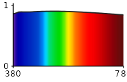

D65

vis  
mel

0.901  
0.901

0.90124  
0.90139

+0.024  
+0.039

+0.026  
+0.043

102  
G2

Double insulating glazing (FG-A-FG)

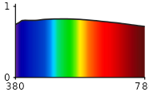

D65

vis  
mel

0.817  
0.818

0.81745  
0.81792

+0.045  
-0.008

+0.055  
-0.010

103  
G3

Double insulating glazing (FG-A-LSG)

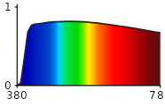

D65

vis  
mel

0.808  
0.807

0.80799  
0.80698

-0.001  
-0.002

-0.001  
-0.003

104  
G4

Double low-e glazing (FG-Ar-TIG1)

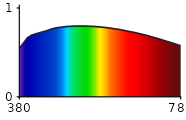

D65

vis  
mel

0.786  
0.778

0.78618  
0.77802

+0.018  
+0.002

+0.023  
+0.003

105  
G5

Double low-e glazing (FG-Ar-TIG2)

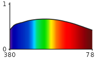

D65

vis  
mel

0.658  
0.640

0.65846  
0.64044

+0.046  
+0.044

+0.070  
+0.068

106  
G6

Double low-e glazing (FG-Ar-TIG3)

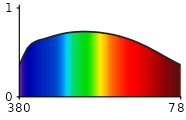

D65

vis  
mel

0.720  
0.703

0.72003  
0.70326

+0.003  
+0.026

+0.004  
+0.037

107  
G7

Double solar-control glazing (SCG1-Ar-FG)

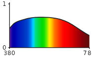

D65

vis  
mel

0.685  
0.673

0.68501  
0.67297

+0.001  
-0.003

+0.001  
-0.005

108  
G8

Double solar-control glazing (SCG2-Ar-FG)

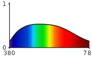

D65

vis  
mel

0.522  
0.509

0.52189  
0.50879

-0.011  
-0.021

-0.022  
-0.041

109  
G9

Double solar-control glazing (SCG3-Ar-FG)

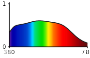

D65

vis  
mel

0.585  
0.568

0.58529  
0.56832

+0.029  
+0.032

+0.050  
+0.057

110  
G10

Triple low-e glazing (TIG1-Ar-FG-A-TIG1)

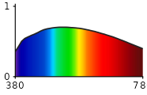

D65

vis  
mel

0.687  
0.674

0.68697  
0.67376

-0.003  
-0.024

-0.004  
-0.036

111  
G11

Triple solar-control glazing (SCG1-Ar-FG-Ar-TIG1)

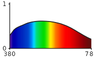

D65

vis  
mel

0.599  
0.583

0.59937  
0.58279

+0.037  
-0.021

+0.062  
-0.036

112  
G12

Triple solar-control glazing (SCG2-Ar-FG-Ar-TIG3)

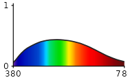

D65

vis  
mel

0.417  
0.399

0.41732  
0.39873

+0.032  
-0.027

+0.077  
-0.069

Within each cell: **vis** (photopic), then **mel** (melanopic). Δ = Spectran − DIN. pp = percentage points; % = relative difference. Bold red Δ values exceed ±0.10 pp. Thumbnails: 380–780 nm; material 0–1; illuminant peak = 1.

#### Materials without an assigned spectrum

No confirmed TUB spectrum is assigned to the following 32 DIN materials. A missing assignment can mean that the named material is absent from the source or that the available descriptions do not establish specimen identity. All entries below are evaluated under D65 in DIN; no substitute spectra are used.

**Calculation**

```r
missing_inventory <- wide |>
  filter(!curve_available) |>
  left_join(select(materials, din_id, group), by = "din_id", relationship = "one-to-one") |>
  arrange(din_id) |>
  select(group, din_id, material, din_vis, din_mel)

stopifnot(nrow(missing_inventory) == 32L)
```

Scroll the table sideways to compare both coefficients. The DIN IDs stay visible.

**Format the missing-material inventory**

```r
missing_inventory |>
  gt(groupname_col = "group") |>
  cols_label(din_id = "DIN ID", material = "Material",
    din_vis = "DIN photopic", din_mel = "DIN melanopic") |>
  fmt_number(columns = c(din_vis, din_mel), decimals = 3) |>
  style_table()
```

Table 5: DIN materials without an assigned TUB spectrum, with their D65 reference coefficients. Multi-skin sheets are from Table 7; plastics and filters are from Table 8.

| DIN ID | Material | DIN photopic | DIN melanopic |
| --- | --- | --- | --- |
| Multi-skin sheets |  |  |  |
| 201 | Type 1, 16 mm, clear | 0.735 | 0.733 |
| 202 | Type 1, 16 mm, diffusing | 0.618 | 0.623 |
| 203 | Type 1, 16 mm, clear, tinted | 0.297 | 0.264 |
| 204 | Type 2, 16 mm, clear | 0.635 | 0.630 |
| 205 | Type 2, 16 mm, diffusing | 0.547 | 0.555 |
| 206 | Type 2, 16 mm, clear, tinted | 0.268 | 0.232 |
| 207 | Type 3, 25 mm, clear | 0.485 | 0.482 |
| 208 | Type 3, 25 mm, diffusing | 0.404 | 0.409 |
| 209 | Type 3, 25 mm, clear, tinted | 0.133 | 0.114 |
| 210 | Type 4, 20 mm, clear | 0.589 | 0.580 |
| 211 | Type 4, 20 mm, diffusing | 0.467 | 0.474 |
| Plastics and filters |  |  |  |
| 301 | Plexiglas GS233 | 0.924 | 0.923 |
| 302 | Plexiglas XT | 0.924 | 0.923 |
| 303 | Plexiglas 7H | 0.921 | 0.920 |
| 304 | Plexiglas 8N | 0.923 | 0.921 |
| 305 | RT95 sun-protection filter | 0.106 | 0.001 |
| 306 | Plexiglas GS blue 602, 3 mm | 0.158 | 0.437 |
| 307 | Plexiglas GS blue 625, 3 mm | 0.617 | 0.750 |
| 308 | Plexiglas GS blue 627, 3 mm | 0.041 | 0.232 |
| 309 | Plexiglas GS brown 400, 3 mm | 0.190 | 0.105 |
| 310 | Plexiglas GS yellow 303, 3 mm | 0.739 | 0.194 |
| 311 | Plexiglas GS grey 837, 3 mm | 0.092 | 0.141 |
| 312 | Plexiglas GS grey 838, 3 mm | 0.210 | 0.232 |
| 313 | Plexiglas GS grey 882, 3 mm | 0.452 | 0.522 |
| 314 | Plexiglas GS green 700, 3 mm | 0.096 | 0.131 |
| 315 | Plexiglas GS green 701, 3 mm | 0.222 | 0.463 |
| 316 | Plexiglas GS green 777, 3 mm | 0.701 | 0.737 |
| 317 | Plexiglas GS orange 478, 3 mm | 0.474 | 0.046 |
| 318 | Plexiglas GS red 501, 3 mm | 0.134 | 0.013 |
| 319 | Plexiglas GS red 502, 3 mm | 0.056 | 0.005 |
| 320 | Plexiglas GS umbra 802, 3 mm | 0.551 | 0.497 |
| 321 | Plexiglas GS umbra 807, 3 mm | 0.471 | 0.526 |

### Reflection

Tables 9 and 10 provide eight illuminants for the same 27 reflecting surfaces. The tabs follow the DIN order. Each table reports both weighting functions and retains all samples, including the FL11 differences.

Each numeric cell lists **photopic (vis)** above **melanopic (mel)** values. Δ = Spectran − DIN; **pp** = percentage points; **%** = relative difference. Bold red Δ values exceed ±0.10 pp.

Scroll the table sideways to compare all columns. The compact DIN/TUB identifiers stay visible.

**EE**

**R code: EE reflection table**

```r
wide |>
  filter(mode == "Reflection", source_id == "CIE:E") |>
  arrange(din_id) |>
  result_table()
```

Table 6: Reflection under EE, DIN Table 9.

DIN  
TUB

Material description

Material

Illuminant

Weight

DIN

Spectran

Δ  
(pp)

Δ  
(%)

401  
WC11

Lachs 20

EE

vis  
mel

0.666  
0.573

0.66600  
0.57314

+0.000  
+0.014

+0.000  
+0.024

402  
WC12

Lachs 30

EE

vis  
mel

0.806  
0.737

0.80618  
0.73743

+0.018  
+0.043

+0.023  
+0.059

403  
WC1

Palazzo 235

EE

vis  
mel

0.775  
0.584

0.77449  
0.58436

-0.051  
+0.036

-0.066  
+0.061

404  
WC2

Palazzo 240

EE

vis  
mel

0.845  
0.775

0.84487  
0.77494

-0.013  
-0.006

-0.015  
-0.008

405  
WC3

Palazzo 90

EE

vis  
mel

0.825  
0.775

0.82465  
0.77515

-0.035  
+0.015

-0.042  
+0.019

406  
WC4

Marill 30

EE

vis  
mel

0.656  
0.618

0.65599  
0.61838

-0.001  
+0.038

-0.001  
+0.061

407  
WC5

Marill 120

EE

vis  
mel

0.776  
0.636

0.77644  
0.63582

+0.044  
-0.018

+0.057  
-0.028

408  
WC6

Siena 150

EE

vis  
mel

0.809  
0.707

0.80909  
0.70746

+0.009  
+0.046

+0.012  
+0.065

409  
WC7

Siena 120

EE

vis  
mel

0.774  
0.677

0.77408  
0.67650

+0.008  
-0.050

+0.010  
-0.073

410  
WC8

Siena 115

EE

vis  
mel

0.742  
0.619

0.74245  
0.61944

+0.045  
+0.044

+0.061  
+0.071

411  
WC9

Ceramic 90

EE

vis  
mel

0.846  
0.803

0.84585  
0.80332

-0.015  
+0.032

-0.017  
+0.040

412  
WC10

Ceramic 60

EE

vis  
mel

0.768  
0.674

0.76844  
0.67398

+0.044  
-0.002

+0.057  
-0.003

413  
S3

Concrete, fine-pored

EE

vis  
mel

0.521  
0.480

0.52065  
0.48004

-0.035  
+0.004

-0.067  
+0.009

414  
S4

Concrete, medium-pored

EE

vis  
mel

0.501  
0.481

0.50131  
0.48049

+0.031  
-0.051

+0.062  
-0.105

415  
S5

Concrete, coarse-pored

EE

vis  
mel

0.463  
0.438

0.46273  
0.43770

-0.027  
-0.030

-0.059  
-0.069

416  
S1

Yellow brick (TUB: beige)

EE

vis  
mel

0.390  
0.237

0.39003  
0.23754

+0.003  
+0.054

+0.008  
+0.226

417  
S2

Brick, red

EE

vis  
mel

0.118  
0.073

0.11832  
0.07304

+0.032  
+0.004

+0.271  
+0.051

418  
WF1

Maple, varnished

EE

vis  
mel

0.563  
0.433

0.56298  
0.43327

-0.002  
+0.027

-0.004  
+0.062

419  
WF3

Beech, varnished

EE

vis  
mel

0.388  
0.252

0.38779  
0.25168

-0.021  
-0.032

-0.055  
-0.126

420  
WF5

Oak, varnished

EE

vis  
mel

0.311  
0.203

0.31092  
0.20319

-0.008  
+0.019

-0.025  
+0.093

421  
WF7

Cherry, varnished

EE

vis  
mel

0.273  
0.164

0.27291  
0.16448

-0.009  
+0.048

-0.034  
+0.290

422  
WF9

Walnut, varnished

EE

vis  
mel

0.133  
0.098

0.13326  
0.09782

+0.026  
-0.018

+0.195  
-0.188

423  
WF2

Maple, oiled

EE

vis  
mel

0.539  
0.391

0.53889  
0.39126

-0.011  
+0.026

-0.021  
+0.067

424  
WF4

Beech, oiled

EE

vis  
mel

0.406  
0.254

0.40632  
0.25361

+0.032  
-0.039

+0.079  
-0.153

425  
WF6

Oak, oiled

EE

vis  
mel

0.355  
0.228

0.35533  
0.22832

+0.033  
+0.032

+0.092  
+0.139

426  
WF8

Cherry, oiled

EE

vis  
mel

0.330  
0.196

0.33020  
0.19618

+0.020  
+0.018

+0.060  
+0.093

427  
WF10

Walnut, oiled

EE

vis  
mel

0.138  
0.089

0.13752  
0.08942

-0.048  
+0.042

-0.349  
+0.471

Within each cell: **vis** (photopic), then **mel** (melanopic). Δ = Spectran − DIN. pp = percentage points; % = relative difference. Bold red Δ values exceed ±0.10 pp. Thumbnails: 380–780 nm; material 0–1; illuminant peak = 1.

**A**

**R code: A reflection table**

```r
wide |>
  filter(mode == "Reflection", source_id == "CIE:A") |>
  arrange(din_id) |>
  result_table()
```

Table 7: Reflection under A, DIN Table 9.

DIN  
TUB

Material description

Material

Illuminant

Weight

DIN

Spectran

Δ  
(pp)

Δ  
(%)

401  
WC11

Lachs 20

A

vis  
mel

0.688  
0.580

0.68792  
0.58035

-0.008  
+0.035

-0.011  
+0.060

402  
WC12

Lachs 30

A

vis  
mel

0.821  
0.743

0.82082  
0.74269

-0.018  
-0.031

-0.022  
-0.042

403  
WC1

Palazzo 235

A

vis  
mel

0.802  
0.616

0.80194  
0.61571

-0.006  
-0.029

-0.007  
-0.047

404  
WC2

Palazzo 240

A

vis  
mel

0.855  
0.789

0.85490  
0.78933

-0.010  
+0.033

-0.011  
+0.042

405  
WC3

Palazzo 90

A

vis  
mel

0.832  
0.786

0.83216  
0.78628

+0.016  
+0.028

+0.020  
+0.035

406  
WC4

Marill 30

A

vis  
mel

0.662  
0.625

0.66186  
0.62508

-0.014  
+0.008

-0.021  
+0.013

407  
WC5

Marill 120

A

vis  
mel

0.798  
0.659

0.79806  
0.65882

+0.006  
-0.018

+0.007  
-0.027

408  
WC6

Siena 150

A

vis  
mel

0.828  
0.719

0.82786  
0.71935

-0.014  
+0.035

-0.017  
+0.048

409  
WC7

Siena 120

A

vis  
mel

0.792  
0.689

0.79194  
0.68949

-0.006  
+0.049

-0.008  
+0.071

410  
WC8

Siena 115

A

vis  
mel

0.765  
0.635

0.76502  
0.63544

+0.002  
+0.044

+0.003  
+0.070

411  
WC9

Ceramic 90

A

vis  
mel

0.854  
0.810

0.85416  
0.80978

+0.016  
-0.022

+0.019  
-0.027

412  
WC10

Ceramic 60

A

vis  
mel

0.788  
0.685

0.78799  
0.68549

-0.001  
+0.049

-0.001  
+0.072

413  
S3

Concrete, fine-pored

A

vis  
mel

0.525  
0.489

0.52515  
0.48925

+0.015  
+0.025

+0.029  
+0.051

414  
S4

Concrete, medium-pored

A

vis  
mel

0.503  
0.486

0.50300  
0.48583

+0.000  
-0.017

+0.000  
-0.035

415  
S5

Concrete, coarse-pored

A

vis  
mel

0.465  
0.444

0.46496  
0.44399

-0.004  
-0.001

-0.010  
-0.003

416  
S1

Yellow brick (TUB: beige)

A

vis  
mel

0.414  
0.260

0.41394  
0.25971

-0.006  
-0.029

-0.014  
-0.113

417  
S2

Brick, red

A

vis  
mel

0.130  
0.076

0.13005  
0.07589

+0.005  
-0.011

+0.038  
-0.144

418  
WF1

Maple, varnished

A

vis  
mel

0.587  
0.453

0.58702  
0.45277

+0.002  
-0.023

+0.003  
-0.050

419  
WF3

Beech, varnished

A

vis  
mel

0.416  
0.268

0.41612  
0.26814

+0.012  
+0.014

+0.029  
+0.054

420  
WF5

Oak, varnished

A

vis  
mel

0.331  
0.219

0.33102  
0.21938

+0.002  
+0.038

+0.006  
+0.174

421  
WF7

Cherry, varnished

A

vis  
mel

0.298  
0.175

0.29812  
0.17547

+0.012  
+0.047

+0.042  
+0.271

422  
WF9

Walnut, varnished

A

vis  
mel

0.141  
0.102

0.14102  
0.10233

+0.002  
+0.033

+0.013  
+0.326

423  
WF2

Maple, oiled

A

vis  
mel

0.566  
0.413

0.56602  
0.41313

+0.002  
+0.013

+0.003  
+0.031

424  
WF4

Beech, oiled

A

vis  
mel

0.437  
0.273

0.43707  
0.27305

+0.007  
+0.005

+0.016  
+0.017

425  
WF6

Oak, oiled

A

vis  
mel

0.379  
0.247

0.37904  
0.24686

+0.004  
-0.014

+0.012  
-0.055

426  
WF8

Cherry, oiled

A

vis  
mel

0.358  
0.213

0.35804  
0.21268

+0.004  
-0.032

+0.010  
-0.150

427  
WF10

Walnut, oiled

A

vis  
mel

0.148  
0.095

0.14793  
0.09534

-0.007  
+0.034

-0.049  
+0.362

Within each cell: **vis** (photopic), then **mel** (melanopic). Δ = Spectran − DIN. pp = percentage points; % = relative difference. Bold red Δ values exceed ±0.10 pp. Thumbnails: 380–780 nm; material 0–1; illuminant peak = 1.

**D65**

**R code: D65 reflection table**

```r
wide |>
  filter(mode == "Reflection", source_id == "CIE:D65") |>
  arrange(din_id) |>
  result_table()
```

Table 8: Reflection under D65, DIN Table 9.

DIN  
TUB

Material description

Material

Illuminant

Weight

DIN

Spectran

Δ  
(pp)

Δ  
(%)

401  
WC11

Lachs 20

D65

vis  
mel

0.659  
0.573

0.65935  
0.57271

+0.035  
-0.029

+0.052  
-0.050

402  
WC12

Lachs 30

D65

vis  
mel

0.802  
0.737

0.80173  
0.73734

-0.027  
+0.034

-0.033  
+0.046

403  
WC1

Palazzo 235

D65

vis  
mel

0.767  
0.582

0.76662  
0.58248

-0.038  
+0.048

-0.049  
+0.083

404  
WC2

Palazzo 240

D65

vis  
mel

0.842  
0.775

0.84199  
0.77468

-0.001  
-0.032

-0.001  
-0.042

405  
WC3

Palazzo 90

D65

vis  
mel

0.822  
0.775

0.82248  
0.77515

+0.048  
+0.015

+0.059  
+0.019

406  
WC4

Marill 30

D65

vis  
mel

0.654  
0.618

0.65427  
0.61844

+0.027  
+0.044

+0.041  
+0.071

407  
WC5

Marill 120

D65

vis  
mel

0.770  
0.635

0.77016  
0.63453

+0.016  
-0.047

+0.021  
-0.074

408  
WC6

Siena 150

D65

vis  
mel

0.804  
0.707

0.80354  
0.70700

-0.046  
+0.000

-0.058  
+0.000

409  
WC7

Siena 120

D65

vis  
mel

0.769  
0.676

0.76888  
0.67632

-0.012  
+0.032

-0.016  
+0.048

410  
WC8

Siena 115

D65

vis  
mel

0.736  
0.619

0.73589  
0.61898

-0.011  
-0.002

-0.015  
-0.003

411  
WC9

Ceramic 90

D65

vis  
mel

0.843  
0.804

0.84336  
0.80362

+0.036  
-0.038

+0.043  
-0.047

412  
WC10

Ceramic 60

D65

vis  
mel

0.763  
0.674

0.76258  
0.67353

-0.042  
-0.047

-0.055  
-0.070

413  
S3

Concrete, fine-pored

D65

vis  
mel

0.519  
0.480

0.51944  
0.47997

+0.044  
-0.003

+0.085  
-0.006

414  
S4

Concrete, medium-pored

D65

vis  
mel

0.501  
0.480

0.50089  
0.48048

-0.011  
+0.048

-0.022  
+0.100

415  
S5

Concrete, coarse-pored

D65

vis  
mel

0.462  
0.438

0.46215  
0.43767

+0.015  
-0.033

+0.032  
-0.075

416  
S1

Yellow brick (TUB: beige)

D65

vis  
mel

0.383  
0.236

0.38329  
0.23639

+0.029  
+0.039

+0.075  
+0.164

417  
S2

Brick, red

D65

vis  
mel

0.115  
0.073

0.11480  
0.07282

-0.020  
-0.018

-0.171  
-0.250

418  
WF1

Maple, varnished

D65

vis  
mel

0.556  
0.433

0.55617  
0.43278

+0.017  
-0.022

+0.031  
-0.052

419  
WF3

Beech, varnished

D65

vis  
mel

0.380  
0.251

0.37964  
0.25082

-0.036  
-0.018

-0.094  
-0.071

420  
WF5

Oak, varnished

D65

vis  
mel

0.305  
0.203

0.30520  
0.20260

+0.020  
-0.040

+0.066  
-0.196

421  
WF7

Cherry, varnished

D65

vis  
mel

0.266  
0.164

0.26558  
0.16391

-0.042  
-0.009

-0.156  
-0.055

422  
WF9

Walnut, varnished

D65

vis  
mel

0.131  
0.098

0.13102  
0.09766

+0.002  
-0.034

+0.017  
-0.352

423  
WF2

Maple, oiled

D65

vis  
mel

0.531  
0.391

0.53115  
0.39065

+0.015  
-0.035

+0.029  
-0.088

424  
WF4

Beech, oiled

D65

vis  
mel

0.397  
0.253

0.39751  
0.25261

+0.051  
-0.039

+0.128  
-0.156

425  
WF6

Oak, oiled

D65

vis  
mel

0.349  
0.228

0.34854  
0.22765

-0.046  
-0.035

-0.131  
-0.155

426  
WF8

Cherry, oiled

D65

vis  
mel

0.322  
0.195

0.32219  
0.19548

+0.019  
+0.048

+0.058  
+0.247

427  
WF10

Walnut, oiled

D65

vis  
mel

0.134  
0.089

0.13451  
0.08918

+0.051  
+0.018

+0.382  
+0.198

Within each cell: **vis** (photopic), then **mel** (melanopic). Δ = Spectran − DIN. pp = percentage points; % = relative difference. Bold red Δ values exceed ±0.10 pp. Thumbnails: 380–780 nm; material 0–1; illuminant peak = 1.

**FL11**

**R code: FL11 reflection table**

```r
wide |>
  filter(mode == "Reflection", source_id == "CIE:FL11") |>
  arrange(din_id) |>
  result_table()
```

Table 9: Reflection under FL11, DIN Table 9. Bold red differences exceed the reproduction limit.

DIN  
TUB

Material description

Material

Illuminant

Weight

DIN

Spectran

Δ  
(pp)

Δ  
(%)

401  
WC11

Lachs 20

FL11

vis  
mel

0.686  
0.576

0.66647  
0.57605

**-1.953**  
+0.005

-2.847  
+0.009

402  
WC12

Lachs 30

FL11

vis  
mel

0.813  
0.740

0.80160  
0.74002

**-1.140**  
+0.002

-1.402  
+0.003

403  
WC1

Palazzo 235

FL11

vis  
mel

0.799  
0.598

0.78200  
0.59834

**-1.700**  
+0.034

-2.128  
+0.056

404  
WC2

Palazzo 240

FL11

vis  
mel

0.854  
0.779

0.84722  
0.77915

**-0.678**  
+0.015

-0.794  
+0.019

405  
WC3

Palazzo 90

FL11

vis  
mel

0.833  
0.777

0.82653  
0.77737

**-0.647**  
+0.037

-0.777  
+0.047

406  
WC4

Marill 30

FL11

vis  
mel

0.661  
0.620

0.65708  
0.62046

**-0.392**  
+0.046

-0.593  
+0.074

407  
WC5

Marill 120

FL11

vis  
mel

0.798  
0.643

0.78200  
0.64332

**-1.600**  
+0.032

-2.005  
+0.049

408  
WC6

Siena 150

FL11

vis  
mel

0.823  
0.713

0.80929  
0.71400

**-1.371**  
+0.100

-1.666  
+0.140

409  
WC7

Siena 120

FL11

vis  
mel

0.795  
0.684

0.78102  
0.68451

**-1.398**  
+0.051

-1.759  
+0.075

410  
WC8

Siena 115

FL11

vis  
mel

0.768  
0.629

0.75087  
0.62925

**-1.713**  
+0.025

-2.230  
+0.039

411  
WC9

Ceramic 90

FL11

vis  
mel

0.852  
0.805

0.84522  
0.80552

**-0.678**  
+0.052

-0.796  
+0.064

412  
WC10

Ceramic 60

FL11

vis  
mel

0.786  
0.676

0.76853  
0.67662

**-1.747**  
+0.062

-2.223  
+0.092

413  
S3

Concrete, fine-pored

FL11

vis  
mel

0.526  
0.484

0.52382  
0.48355

**-0.218**  
-0.045

-0.415  
-0.093

414  
S4

Concrete, medium-pored

FL11

vis  
mel

0.503  
0.483

0.50309  
0.48248

+0.009  
-0.052

+0.017  
-0.107

415  
S5

Concrete, coarse-pored

FL11

vis  
mel

0.465  
0.440

0.46479  
0.43998

-0.021  
-0.002

-0.045  
-0.005

416  
S1

Yellow brick (TUB: beige)

FL11

vis  
mel

0.417  
0.254

0.40362  
0.25413

**-1.338**  
+0.013

-3.209  
+0.053

417  
S2

Brick, red

FL11

vis  
mel

0.131  
0.075

0.12030  
0.07533

**-1.070**  
+0.033

-8.166  
+0.436

418  
WF1

Maple, varnished

FL11

vis  
mel

0.589  
0.445

0.57299  
0.44526

**-1.601**  
+0.026

-2.719  
+0.058

419  
WF3

Beech, varnished

FL11

vis  
mel

0.416  
0.263

0.39645  
0.26334

**-1.955**  
+0.034

-4.700  
+0.129

420  
WF5

Oak, varnished

FL11

vis  
mel

0.331  
0.212

0.31760  
0.21206

**-1.340**  
+0.006

-4.047  
+0.030

421  
WF7

Cherry, varnished

FL11

vis  
mel

0.297  
0.173

0.27857  
0.17283

**-1.843**  
-0.017

-6.204  
-0.097

422  
WF9

Walnut, varnished

FL11

vis  
mel

0.140  
0.100

0.13485  
0.10031

**-0.515**  
+0.031

-3.675  
+0.307

423  
WF2

Maple, oiled

FL11

vis  
mel

0.567  
0.404

0.54920  
0.40417

**-1.780**  
+0.017

-3.139  
+0.042

424  
WF4

Beech, oiled

FL11

vis  
mel

0.438  
0.267

0.41679  
0.26683

**-2.121**  
-0.017

-4.843  
-0.064

425  
WF6

Oak, oiled

FL11

vis  
mel

0.379  
0.239

0.36317  
0.23879

**-1.583**  
-0.021

-4.178  
-0.087

426  
WF8

Cherry, oiled

FL11

vis  
mel

0.358  
0.208

0.33869  
0.20758

**-1.931**  
-0.042

-5.395  
-0.204

427  
WF10

Walnut, oiled

FL11

vis  
mel

0.147  
0.093

0.13992  
0.09292

**-0.708**  
-0.008

-4.814  
-0.081

Within each cell: **vis** (photopic), then **mel** (melanopic). Δ = Spectran − DIN. pp = percentage points; % = relative difference. Bold red Δ values exceed ±0.10 pp. Thumbnails: 380–780 nm; material 0–1; illuminant peak = 1.

**LED-B1**

**R code: LED-B1 reflection table**

```r
wide |>
  filter(mode == "Reflection", source_id == "CIE:LED_B1") |>
  arrange(din_id) |>
  result_table()
```

Table 10: Reflection under LED-B1, DIN Table 10.

DIN  
TUB

Material description

Material

Illuminant

Weight

DIN

Spectran

Δ  
(pp)

Δ  
(%)

401  
WC11

Lachs 20

LED-B1

vis  
mel

0.694  
0.583

0.69357  
0.58287

-0.043  
-0.013

-0.062  
-0.022

402  
WC12

Lachs 30

LED-B1

vis  
mel

0.826  
0.745

0.82636  
0.74491

+0.036  
-0.009

+0.043  
-0.013

403  
WC1

Palazzo 235

LED-B1

vis  
mel

0.811  
0.617

0.81044  
0.61733

-0.056  
+0.033

-0.069  
+0.054

404  
WC2

Palazzo 240

LED-B1

vis  
mel

0.857  
0.788

0.85745  
0.78771

+0.045  
-0.029

+0.052  
-0.037

405  
WC3

Palazzo 90

LED-B1

vis  
mel

0.833  
0.785

0.83340  
0.78469

+0.040  
-0.031

+0.048  
-0.040

406  
WC4

Marill 30

LED-B1

vis  
mel

0.664  
0.626

0.66369  
0.62549

-0.031  
-0.051

-0.047  
-0.081

407  
WC5

Marill 120

LED-B1

vis  
mel

0.804  
0.660

0.80433  
0.66026

+0.033  
+0.026

+0.041  
+0.039

408  
WC6

Siena 150

LED-B1

vis  
mel

0.834  
0.722

0.83404  
0.72168

+0.004  
-0.032

+0.005  
-0.044

409  
WC7

Siena 120

LED-B1

vis  
mel

0.797  
0.692

0.79664  
0.69232

-0.036  
+0.032

-0.045  
+0.046

410  
WC8

Siena 115

LED-B1

vis  
mel

0.771  
0.639

0.77078  
0.63877

-0.022  
-0.023

-0.029  
-0.035

411  
WC9

Ceramic 90

LED-B1

vis  
mel

0.857  
0.810

0.85666  
0.80978

-0.034  
-0.022

-0.039  
-0.027

412  
WC10

Ceramic 60

LED-B1

vis  
mel

0.793  
0.686

0.79261  
0.68592

-0.039  
-0.008

-0.049  
-0.012

413  
S3

Concrete, fine-pored

LED-B1

vis  
mel

0.526  
0.489

0.52647  
0.48915

+0.047  
+0.015

+0.089  
+0.031

414  
S4

Concrete, medium-pored

LED-B1

vis  
mel

0.504  
0.486

0.50374  
0.48570

-0.026  
-0.030

-0.052  
-0.062

415  
S5

Concrete, coarse-pored

LED-B1

vis  
mel

0.466  
0.444

0.46580  
0.44375

-0.020  
-0.025

-0.043  
-0.057

416  
S1

Yellow brick (TUB: beige)

LED-B1

vis  
mel

0.420  
0.264

0.41993  
0.26406

-0.007  
+0.006

-0.016  
+0.023

417  
S2

Brick, red

LED-B1

vis  
mel

0.132  
0.077

0.13208  
0.07693

+0.008  
-0.007

+0.059  
-0.086

418  
WF1

Maple, varnished

LED-B1

vis  
mel

0.589  
0.455

0.58904  
0.45486

+0.004  
-0.014

+0.007  
-0.031

419  
WF3

Beech, varnished

LED-B1

vis  
mel

0.418  
0.271

0.41817  
0.27083

+0.017  
-0.017

+0.041  
-0.062

420  
WF5

Oak, varnished

LED-B1

vis  
mel

0.332  
0.220

0.33249  
0.22031

+0.049  
+0.031

+0.148  
+0.142

421  
WF7

Cherry, varnished

LED-B1

vis  
mel

0.299  
0.178

0.29942  
0.17779

+0.042  
-0.021

+0.139  
-0.120

422  
WF9

Walnut, varnished

LED-B1

vis  
mel

0.141  
0.103

0.14114  
0.10266

+0.014  
-0.034

+0.102  
-0.331

423  
WF2

Maple, oiled

LED-B1

vis  
mel

0.569  
0.415

0.56933  
0.41541

+0.033  
+0.041

+0.058  
+0.098

424  
WF4

Beech, oiled

LED-B1

vis  
mel

0.440  
0.276

0.43955  
0.27601

-0.045  
+0.001

-0.101  
+0.004

425  
WF6

Oak, oiled

LED-B1

vis  
mel

0.382  
0.248

0.38163  
0.24821

-0.037  
+0.021

-0.097  
+0.085

426  
WF8

Cherry, oiled

LED-B1

vis  
mel

0.360  
0.215

0.36027  
0.21531

+0.027  
+0.031

+0.074  
+0.144

427  
WF10

Walnut, oiled

LED-B1

vis  
mel

0.148  
0.096

0.14840  
0.09599

+0.040  
-0.001

+0.273  
-0.011

Within each cell: **vis** (photopic), then **mel** (melanopic). Δ = Spectran − DIN. pp = percentage points; % = relative difference. Bold red Δ values exceed ±0.10 pp. Thumbnails: 380–780 nm; material 0–1; illuminant peak = 1.

**LED-B2**

**R code: LED-B2 reflection table**

```r
wide |>
  filter(mode == "Reflection", source_id == "CIE:LED_B2") |>
  arrange(din_id) |>
  result_table()
```

Table 11: Reflection under LED-B2, DIN Table 10.

DIN  
TUB

Material description

Material

Illuminant

Weight

DIN

Spectran

Δ  
(pp)

Δ  
(%)

401  
WC11

Lachs 20

LED-B2

vis  
mel

0.689  
0.581

0.68871  
0.58141

-0.029  
+0.041

-0.042  
+0.070

402  
WC12

Lachs 30

LED-B2

vis  
mel

0.823  
0.744

0.82325  
0.74383

+0.025  
-0.017

+0.030  
-0.022

403  
WC1

Palazzo 235

LED-B2

vis  
mel

0.805  
0.611

0.80531  
0.61104

+0.031  
+0.004

+0.039  
+0.006

404  
WC2

Palazzo 240

LED-B2

vis  
mel

0.855  
0.785

0.85548  
0.78488

+0.048  
-0.012

+0.056  
-0.015

405  
WC3

Palazzo 90

LED-B2

vis  
mel

0.832  
0.783

0.83188  
0.78263

-0.012  
-0.037

-0.014  
-0.048

406  
WC4

Marill 30

LED-B2

vis  
mel

0.663  
0.624

0.66251  
0.62438

-0.049  
+0.038

-0.074  
+0.061

407  
WC5

Marill 120

LED-B2

vis  
mel

0.800  
0.656

0.80008  
0.65583

+0.008  
-0.017

+0.010  
-0.025

408  
WC6

Siena 150

LED-B2

vis  
mel

0.830  
0.719

0.83023  
0.71933

+0.023  
+0.033

+0.028  
+0.046

409  
WC7

Siena 120

LED-B2

vis  
mel

0.793  
0.690

0.79305  
0.69012

+0.005  
+0.012

+0.006  
+0.018

410  
WC8

Siena 115

LED-B2

vis  
mel

0.766  
0.636

0.76626  
0.63592

+0.026  
-0.008

+0.033  
-0.012

411  
WC9

Ceramic 90

LED-B2

vis  
mel

0.855  
0.809

0.85485  
0.80866

-0.015  
-0.034

-0.018  
-0.042

412  
WC10

Ceramic 60

LED-B2

vis  
mel

0.788  
0.684

0.78842  
0.68354

+0.042  
-0.046

+0.053  
-0.067

413  
S3

Concrete, fine-pored

LED-B2

vis  
mel

0.526  
0.488

0.52573  
0.48755

-0.027  
-0.045

-0.052  
-0.092

414  
S4

Concrete, medium-pored

LED-B2

vis  
mel

0.504  
0.485

0.50351  
0.48479

-0.049  
-0.021

-0.098  
-0.043

415  
S5

Concrete, coarse-pored

LED-B2

vis  
mel

0.465  
0.443

0.46547  
0.44266

+0.047  
-0.034

+0.101  
-0.077

416  
S1

Yellow brick (TUB: beige)

LED-B2

vis  
mel

0.416  
0.260

0.41564  
0.25996

-0.036  
-0.004

-0.086  
-0.015

417  
S2

Brick, red

LED-B2

vis  
mel

0.130  
0.076

0.12954  
0.07628

-0.046  
+0.028

-0.354  
+0.373

418  
WF1

Maple, varnished

LED-B2

vis  
mel

0.585  
0.451

0.58460  
0.45135

-0.040  
+0.035

-0.069  
+0.078

419  
WF3

Beech, varnished

LED-B2

vis  
mel

0.413  
0.268

0.41280  
0.26763

-0.020  
-0.037

-0.049  
-0.137

420  
WF5

Oak, varnished

LED-B2

vis  
mel

0.329  
0.217

0.32878  
0.21723

-0.022  
+0.023

-0.067  
+0.106

421  
WF7

Cherry, varnished

LED-B2

vis  
mel

0.294  
0.176

0.29450  
0.17561

+0.050  
-0.039

+0.170  
-0.220

422  
WF9

Walnut, varnished

LED-B2

vis  
mel

0.140  
0.102

0.13967  
0.10178

-0.033  
-0.022

-0.238  
-0.211

423  
WF2

Maple, oiled

LED-B2

vis  
mel

0.564  
0.411

0.56423  
0.41142

+0.023  
+0.042

+0.040  
+0.102

424  
WF4

Beech, oiled

LED-B2

vis  
mel

0.434  
0.272

0.43375  
0.27228

-0.025  
+0.028

-0.058  
+0.102

425  
WF6

Oak, oiled

LED-B2

vis  
mel

0.377  
0.245

0.37717  
0.24468

+0.017  
-0.032

+0.044  
-0.131

426  
WF8

Cherry, oiled

LED-B2

vis  
mel

0.355  
0.212

0.35495  
0.21218

-0.005  
+0.018

-0.013  
+0.083

427  
WF10

Walnut, oiled

LED-B2

vis  
mel

0.146  
0.095

0.14641  
0.09484

+0.041  
-0.016

+0.279  
-0.166

Within each cell: **vis** (photopic), then **mel** (melanopic). Δ = Spectran − DIN. pp = percentage points; % = relative difference. Bold red Δ values exceed ±0.10 pp. Thumbnails: 380–780 nm; material 0–1; illuminant peak = 1.

**LED-B3**

**R code: LED-B3 reflection table**

```r
wide |>
  filter(mode == "Reflection", source_id == "CIE:LED_B3") |>
  arrange(din_id) |>
  result_table()
```

Table 12: Reflection under LED-B3, DIN Table 10.

DIN  
TUB

Material description

Material

Illuminant

Weight

DIN

Spectran

Δ  
(pp)

Δ  
(%)

401  
WC11

Lachs 20

LED-B3

vis  
mel

0.675  
0.578

0.67515  
0.57816

+0.015  
+0.016

+0.022  
+0.028

402  
WC12

Lachs 30

LED-B3

vis  
mel

0.814  
0.741

0.81401  
0.74113

+0.001  
+0.013

+0.002  
+0.017

403  
WC1

Palazzo 235

LED-B3

vis  
mel

0.790  
0.598

0.78970  
0.59766

-0.030  
-0.034

-0.039  
-0.057

404  
WC2

Palazzo 240

LED-B3

vis  
mel

0.850  
0.779

0.84973  
0.77921

-0.027  
+0.021

-0.031  
+0.027

405  
WC3

Palazzo 90

LED-B3

vis  
mel

0.828  
0.779

0.82762  
0.77853

-0.038  
-0.047

-0.046  
-0.060

406  
WC4

Marill 30

LED-B3

vis  
mel

0.659  
0.622

0.65907  
0.62173

+0.007  
-0.027

+0.010  
-0.043

407  
WC5

Marill 120

LED-B3

vis  
mel

0.788  
0.647

0.78764  
0.64654

-0.036  
-0.046

-0.046  
-0.070

408  
WC6

Siena 150

LED-B3

vis  
mel

0.819  
0.714

0.81887  
0.71388

-0.013  
-0.012

-0.016  
-0.017

409  
WC7

Siena 120

LED-B3

vis  
mel

0.783  
0.684

0.78250  
0.68435

-0.050  
+0.035

-0.063  
+0.051

410  
WC8

Siena 115

LED-B3

vis  
mel

0.753  
0.629

0.75297  
0.62868

-0.003  
-0.032

-0.004  
-0.052

411  
WC9

Ceramic 90

LED-B3

vis  
mel

0.850  
0.806

0.84969  
0.80611

-0.031  
+0.011

-0.036  
+0.014

412  
WC10

Ceramic 60

LED-B3

vis  
mel

0.777  
0.679

0.77659  
0.67858

-0.041  
-0.042

-0.053  
-0.062

413  
S3

Concrete, fine-pored

LED-B3

vis  
mel

0.523  
0.484

0.52333  
0.48361

+0.033  
-0.039

+0.064  
-0.081

414  
S4

Concrete, medium-pored

LED-B3

vis  
mel

0.503  
0.483

0.50267  
0.48253

-0.033  
-0.047

-0.066  
-0.098

415  
S5

Concrete, coarse-pored

LED-B3

vis  
mel

0.464  
0.440

0.46433  
0.43996

+0.033  
-0.004

+0.072  
-0.009

416  
S1

Yellow brick (TUB: beige)

LED-B3

vis  
mel

0.402  
0.250

0.40226  
0.24974

+0.026  
-0.026

+0.064  
-0.102

417  
S2

Brick, red

LED-B3

vis  
mel

0.122  
0.075

0.12242  
0.07472

+0.042  
-0.028

+0.344  
-0.374

418  
WF1

Maple, varnished

LED-B3

vis  
mel

0.571  
0.443

0.57134  
0.44278

+0.034  
-0.022

+0.060  
-0.050

419  
WF3

Beech, varnished

LED-B3

vis  
mel

0.397  
0.260

0.39696  
0.26015

-0.004  
+0.015

-0.011  
+0.058

420  
WF5

Oak, varnished

LED-B3

vis  
mel

0.318  
0.210

0.31772  
0.21001

-0.028  
+0.001

-0.087  
+0.004

421  
WF7

Cherry, varnished

LED-B3

vis  
mel

0.280  
0.170

0.28023  
0.17045

+0.023  
+0.045

+0.082  
+0.263

422  
WF9

Walnut, varnished

LED-B3

vis  
mel

0.135  
0.100

0.13537  
0.09974

+0.037  
-0.026

+0.271  
-0.265

423  
WF2

Maple, oiled

LED-B3

vis  
mel

0.549  
0.402

0.54905  
0.40177

+0.005  
-0.023

+0.009  
-0.056

424  
WF4

Beech, oiled

LED-B3

vis  
mel

0.417  
0.264

0.41660  
0.26360

-0.040  
-0.040

-0.095  
-0.152

425  
WF6

Oak, oiled

LED-B3

vis  
mel

0.364  
0.236

0.36392  
0.23638

-0.008  
+0.038

-0.023  
+0.162

426  
WF8

Cherry, oiled

LED-B3

vis  
mel

0.339  
0.205

0.33932  
0.20466

+0.032  
-0.034

+0.095  
-0.167

427  
WF10

Walnut, oiled

LED-B3

vis  
mel

0.141  
0.092

0.14058  
0.09215

-0.042  
+0.015

-0.294  
+0.163

Within each cell: **vis** (photopic), then **mel** (melanopic). Δ = Spectran − DIN. pp = percentage points; % = relative difference. Bold red Δ values exceed ±0.10 pp. Thumbnails: 380–780 nm; material 0–1; illuminant peak = 1.

**LED-B5**

**R code: LED-B5 reflection table**

```r
wide |>
  filter(mode == "Reflection", source_id == "CIE:LED_B5") |>
  arrange(din_id) |>
  result_table()
```

Table 13: Reflection under LED-B5, DIN Table 10.

DIN  
TUB

Material description

Material

Illuminant

Weight

DIN

Spectran

Δ  
(pp)

Δ  
(%)

401  
WC11

Lachs 20

LED-B5

vis  
mel

0.662  
0.575

0.66160  
0.57461

-0.040  
-0.039

-0.061  
-0.067

402  
WC12

Lachs 30

LED-B5

vis  
mel

0.805  
0.739

0.80530  
0.73891

+0.030  
-0.009

+0.037  
-0.013

403  
WC1

Palazzo 235

LED-B5

vis  
mel

0.775  
0.578

0.77477  
0.57789

-0.023  
-0.011

-0.030  
-0.019

404  
WC2

Palazzo 240

LED-B5

vis  
mel

0.844  
0.769

0.84370  
0.76918

-0.030  
+0.018

-0.035  
+0.023

405  
WC3

Palazzo 90

LED-B5

vis  
mel

0.823  
0.771

0.82288  
0.77072

-0.012  
-0.028

-0.014  
-0.036

406  
WC4

Marill 30

LED-B5

vis  
mel

0.656  
0.618

0.65566  
0.61805

-0.034  
+0.005

-0.052  
+0.008

407  
WC5

Marill 120

LED-B5

vis  
mel

0.775  
0.632

0.77526  
0.63207

+0.026  
+0.007

+0.033  
+0.012

408  
WC6

Siena 150

LED-B5

vis  
mel

0.808  
0.708

0.80809  
0.70756

+0.009  
-0.044

+0.011  
-0.062

409  
WC7

Siena 120

LED-B5

vis  
mel

0.772  
0.678

0.77237  
0.67841

+0.037  
+0.041

+0.048  
+0.061

410  
WC8

Siena 115

LED-B5

vis  
mel

0.740  
0.621

0.74021  
0.62099

+0.021  
-0.001

+0.028  
-0.002

411  
WC9

Ceramic 90

LED-B5

vis  
mel

0.844  
0.803

0.84447  
0.80250

+0.047  
-0.050

+0.055  
-0.062

412  
WC10

Ceramic 60

LED-B5

vis  
mel

0.765  
0.671

0.76457  
0.67120

-0.043  
+0.020

-0.057  
+0.030

413  
S3

Concrete, fine-pored

LED-B5

vis  
mel

0.521  
0.478

0.52104  
0.47829

+0.004  
+0.029

+0.008  
+0.061

414  
S4

Concrete, medium-pored

LED-B5

vis  
mel

0.502  
0.479

0.50190  
0.47944

-0.010  
+0.044

-0.020  
+0.092

415  
S5

Concrete, coarse-pored

LED-B5

vis  
mel

0.463  
0.436

0.46326  
0.43628

+0.026  
+0.028

+0.057  
+0.065

416  
S1

Yellow brick (TUB: beige)

LED-B5

vis  
mel

0.390  
0.238

0.39004  
0.23848

+0.004  
+0.048

+0.011  
+0.202

417  
S2

Brick, red

LED-B5

vis  
mel

0.115  
0.073

0.11528  
0.07332

+0.028  
+0.032

+0.243  
+0.436

418  
WF1

Maple, varnished

LED-B5

vis  
mel

0.558  
0.432

0.55836  
0.43230

+0.036  
+0.030

+0.064  
+0.069

419  
WF3

Beech, varnished

LED-B5

vis  
mel

0.381  
0.251

0.38140  
0.25110

+0.040  
+0.010

+0.104  
+0.040

420  
WF5

Oak, varnished

LED-B5

vis  
mel

0.307  
0.201

0.30681  
0.20052

-0.019  
-0.048

-0.063  
-0.239

421  
WF7

Cherry, varnished

LED-B5

vis  
mel

0.266  
0.165

0.26607  
0.16466

+0.007  
-0.034

+0.026  
-0.208

422  
WF9

Walnut, varnished

LED-B5

vis  
mel

0.131  
0.097

0.13105  
0.09709

+0.005  
+0.009

+0.037  
+0.097

423  
WF2

Maple, oiled

LED-B5

vis  
mel

0.534  
0.390

0.53419  
0.38984

+0.019  
-0.016

+0.036  
-0.042

424  
WF4

Beech, oiled

LED-B5

vis  
mel

0.400  
0.253

0.39976  
0.25282

-0.024  
-0.018

-0.059  
-0.073

425  
WF6

Oak, oiled

LED-B5

vis  
mel

0.351  
0.226

0.35088  
0.22564

-0.012  
-0.036

-0.036  
-0.158

426  
WF8

Cherry, oiled

LED-B5

vis  
mel

0.324  
0.196

0.32396  
0.19582

-0.004  
-0.018

-0.012  
-0.093

427  
WF10

Walnut, oiled

LED-B5

vis  
mel

0.135  
0.089

0.13478  
0.08877

-0.022  
-0.023

-0.165  
-0.254

Within each cell: **vis** (photopic), then **mel** (melanopic). Δ = Spectran − DIN. pp = percentage points; % = relative difference. Bold red Δ values exceed ±0.10 pp. Thumbnails: 380–780 nm; material 0–1; illuminant peak = 1.

## Conclusion

**Derive the conclusion from this run**

```r
outside <- filter(paired, !within_budget)
cat(sprintf(paste0(
  "**%d of %d confirmed coefficients** lie within the project reproduction limit of ±0.001; ",
  "%d already lie within the stricter rounding interval of ±0.0005. ",
  "The remaining %d coefficients exceed the reproduction limit.\n\n"
), sum(paired$within_budget), nrow(paired), sum(paired$within_rounding), nrow(outside)))
```

**431 of 456 confirmed coefficients** lie within the project reproduction limit of ±0.001; 417 already lie within the stricter rounding interval of ±0.0005. The remaining 25 coefficients exceed the reproduction limit.

**Derive the conclusion from this run**

```r
if (nrow(outside)) {
  affected <- outside |> distinct(mode, response, illuminant)
  if (nrow(affected) == 1L) {
    cat(sprintf("All exceedances concern **%s %s under %s**.\n\n",
      tolower(response_labels[affected$response]), tolower(affected$mode), affected$illuminant))
  }

  worst <- slice_max(outside, abs(difference_pp), n = 1, with_ties = FALSE)
  cat(sprintf(paste0(
    "The largest absolute difference is **DIN %d, %s, %s**: ",
    "DIN %s, Spectran %s, Δ %s percentage points.\n\n"
  ), worst$din_id, worst$material, worst$illuminant,
    fmt(worst$din, 3), fmt(worst$spectran, 6), fmt(worst$difference_pp, 4)))
}
```

All exceedances concern **photopic reflection under FL11**.

The largest absolute difference is **DIN 424, Beech, oiled, FL11**: DIN 0.438, Spectran 0.416790, Δ -2.1210 percentage points.

The module and the explicit weighted sums agree for all tested inputs.

The DIN photopic reflection coefficients for FL11 have a known deviation from the correct values. According to the author of the DIN source, Spectran calculates these coefficients correctly, and a correction of the DIN values is planned for the next edition of DIN/TS 67600.[^1]

For the remaining **32 DIN materials**, no confirmed spectrum is assigned. Two integrated coefficients are insufficient to reconstruct a unique material spectrum. A complete spectral validation of all 71 DIN materials is therefore not supported by the available specimen documentation.

These checks assess numerical reproduction for documented spectra and calculation conventions. They do not replace independent material measurements. Applying the values to an actual room or product still requires the relevant specimen properties and measurement geometry.

## Reproduction

### Inputs and exports

This article runs from the Spectran source tree. Supplying `output-dir`, or the environment variable `SPECTRAN_MATERIAL_OUTPUT_DIR`, writes the unrounded results as CSV and an R object. `comparison-long.csv` includes weighted numerators and denominators; `comparison-wide.csv` places the two responses side by side. `material-map.csv` records the source column for every confirmed assignment. The data behind the overview figure and both sets of thumbnails are also exported as CSV. Without an explicit output directory, these files are written to `data-raw/intermediate/material-validation/`.

**Export results and record input checksums**

```r
input_files <- file.path(root, c(
  "DESCRIPTION", "renv.lock", "R/sysdata.rda", "data/Specs.rda", "data/ColorP.rda",
  "data/examplespectra.rda", "data/examplespectra_descriptor.rda",
  "R/spectral_metrics.R", "R/transmission_core.R", "R/material_core.R",
  "R/material_light_level.R", "R/transmission_catalogue.R", "R/import_verifier.R",
  "inst/extdata/tub/Spectral_transmittance.csv", "inst/extdata/tub/Spectral_reflectance.csv",
  "vignettes/articles/Material_Validation.qmd", "vignettes/articles/Material_Validation.css"
))
input_files <- c(input_files, din_file, assignment_file)
stopifnot(all(file.exists(input_files)))
input_hashes <- tibble(
  File = substring(input_files, nchar(root) + 2L),
  MD5 = unname(tools::md5sum(input_files))
)

output_dir <- params[["output-dir"]]
if (!nzchar(output_dir)) output_dir <- Sys.getenv("SPECTRAN_MATERIAL_OUTPUT_DIR", "")
if (!nzchar(output_dir)) output_dir <- file.path(root, "data-raw/intermediate/material-validation")
dir.create(output_dir, recursive = TRUE, showWarnings = FALSE)

material_thumbnail_data <- list_rbind(material_thumbnails, names_to = "catalogue_id")
source_thumbnail_data <- list_rbind(source_thumbnails, names_to = "source_id")
outputs <- list(
  "comparison-long" = comparison, "comparison-wide" = wide,
  "summary-by-response" = summary_by_response, "summary-by-source" = summary_by_source,
  "material-map" = materials, "source-inventory" = sources,
  "missing-materials" = missing_inventory, "input-hashes" = input_hashes,
  "figure-overview-data" = figure_overview_data,
  "material-thumbnails-data" = material_thumbnail_data,
  "source-thumbnails-data" = source_thumbnail_data
)
iwalk(outputs, function(data, name) {
  write.csv(data, file.path(output_dir, paste0(name, ".csv")), row.names = FALSE, na = "")
})

saveRDS(list(calculated = calculated, comparison = comparison,
  example_terms = example_terms, inputs = input_hashes),
  file.path(output_dir, "validation-results.rds"))
writeLines(capture.output(sessionInfo()), file.path(output_dir, "sessionInfo.txt"))
```

**Input files and checksums for this render**

**Format the input manifest**

```r
input_hashes |>
  gt() |>
  style_table() |>
  tab_options(table.font.size = px(11))
```

Table 14: Input provenance for this render. Paths are relative to the package root where possible.

| File | MD5 |
| --- | --- |
| DESCRIPTION | 9bd5f03dd03e88361c51dabaf08ad9e0 |
| renv.lock | 69cfe4789487d2c8e49dac6c306574bb |
| R/sysdata.rda | cffd8b740f522fc84af73913ab0edb11 |
| data/Specs.rda | 90a9bbcef9bf7ccbb1429cac2145f98e |
| data/ColorP.rda | 8016fb41e1d02c8e07e0ad42f512424e |
| data/examplespectra.rda | edb897f3f8d7a0d845e8741f9481b296 |
| data/examplespectra_descriptor.rda | 4fd7a8a462bc893b42db0ff1eb12e58f |
| R/spectral_metrics.R | f074ef6ca76f4588ef28ac960f035815 |
| R/transmission_core.R | 7d2030d7a2f2ab7ad4961c668563ef7f |
| R/material_core.R | 05b12b1d69551516739c8eb0f2362e89 |
| R/material_light_level.R | 337c99eb6f91b2f197986216246a1773 |
| R/transmission_catalogue.R | 7ad87b23814786d94da9055788fff5da |
| R/import_verifier.R | 40cb873dd14e0ebb253e1c86f5a26aa4 |
| inst/extdata/tub/Spectral_transmittance.csv | 5dbe247ebda24796eac44e2405f00bb7 |
| inst/extdata/tub/Spectral_reflectance.csv | 8b9e994d68d0327428a86b1ed536f772 |
| vignettes/articles/Material_Validation.qmd | 7cc84ec760ac56016281f931e80c1778 |
| vignettes/articles/Material_Validation.css | 38db57d9f51ba12ffd6bf24731ee2892 |
| vignettes/articles/material-validation-data/din-67600-material-coefficients.csv | dbd293e23ec5d33b6f521e2d55fe4f9c |
| vignettes/articles/material-validation-data/tub-assignments.csv | 5dfd2f6c4393572e81edd0285ab5bcb5 |

### Render commands

The prepared CSV is included with the article. From the package root, render the standalone article with:

```bash
quarto render vignettes/articles/Material_Validation.qmd
```

To choose a directory for the unrounded results and plot data:

```bash
quarto render vignettes/articles/Material_Validation.qmd \
  -P output-dir:/path/material-validation
```

The same Quarto source is registered in pkgdown’s Articles menu. The website build requires **pkgdown ≥ 2.2.1**, the R package **quarto**, and a Quarto CLI:

```r
pkgdown::build_site(preview = FALSE)
```

CSV preparation can be repeated separately using `data-raw/prepare_din_material_coefficients.R` and a local, licensed text extraction. Neither the licensed PDF nor its extracted text is needed to render the article.

### Software

The version table describes the R environment and Quarto tools used for this render.

**Collect the software versions**

```r
packages <- c("Spectran", "pkgload", "dplyr", "tidyr", "purrr", "ggplot2", "gt",
  "knitr", "rmarkdown", "pkgdown", "quarto")
software_versions <- tibble(
  Component = c("R", "Quarto CLI", packages),
  Version = c(as.character(getRversion()), system2("quarto", "--version", stdout = TRUE),
    map_chr(packages, function(p) as.character(packageVersion(p))))
)
write.csv(software_versions, file.path(output_dir, "software-versions.csv"), row.names = FALSE)
```

**Format the software record**

```r
software_versions |>
  gt() |>
  style_table()
```

Table 15: Software versions used to render this article.

| Component | Version |
| --- | --- |
| R | 4.6.1 |
| Quarto CLI | 1.9.37 |
| Spectran | 2.0.0.9000 |
| pkgload | 1.5.3 |
| dplyr | 1.2.1 |
| tidyr | 1.3.2 |
| purrr | 1.2.2 |
| ggplot2 | 4.0.3 |
| gt | 1.4.0 |
| knitr | 1.52 |
| rmarkdown | 2.32 |
| pkgdown | 2.2.1 |
| quarto | 1.5.1 |

The reference basis is DIN/TS 67600:2022-08, Section 6.2.4 and Tables 6–10, and the [TUB dataset, version 2](https://doi.org/10.14279/depositonce-11893.2). The weighting functions and bundled illuminants are also described in Underlying values.